# Logistic Regression - TP 10

Emily Schmidt

2022-12-16

## **Exercises & Overall Questions**

For the following assignment, answer the these questions:  
**1.** *Perform the complete analysis of the data set Abonnements. What could you suggest to the commercial director about which factors influence the clients’ choice?*

**2.** *Analyze the data set Ronflement to determine the characteristics of a typical snorer.*

### Load Packages and Data

```r
library(data.table) # Fast aggregation of large data sets and a fast file reader
library(lubridate) # Commute date-times
library(ggplot2) # Provides helpful commands to create complex plots from data in a data frame
library(robust) # Compute an analysis of variance table for one or more robust generalized linear model fits.
library(ellipse) # Contains various routines for drawing ellipses and ellipse-like confidence regions
library(plotly) # Makes interactive, publication-quality graphs
library(GGally) # Allows to build a great scatterplot matrix
library(tidyr) # Can be used to “gather” a key-value pair across multiple columns
library(cowplot) # Arrange plots into a grid and label them
library(kableExtra)  # Tables
library(DataExplorer) # Used to graph missing value percentages
library(naniar) # Missing values analysis
```

```r
setwd("C:\\Users\\emann\\R Data Files") # Set directory
getwd() # Check the working directory
```

```
## [1] "C:/Users/emann/R Data Files"
```

```r
# Read in each data set and bring in your sources for specific code
Abonnements = read.csv("Abonnements.csv", header = TRUE, sep = ',')
Ronflement = read.csv("Ronflement.csv", header = TRUE, sep = ',')

source("PlotResidLogist.R") # Plots deviance residuals and Pearson residuals of a classical logistic regression fit

source("PlotResidLogistRob.R")# Plots deviance residuals and Pearson residuals of a robust logistic regression fit

source("HosLemTest.R") # Goodness of fit test to compare the differences between the binary logistic regression model and the observed data

source("PairsLab.R") # Shows the levels of a categorical variable for each observation on the scatterplot

require(robustbase)
```

## **1 Exploratory Data Analysis**

```r
# Get or set the dimension of the specified matrix, array or data frame
dim(Abonnements)
```

```
## [1] 60  4
```

```r
 # Use kable to design table
kable(head(Abonnements)) %>% kable_classic() %>%
  kableExtra::kable_styling(bootstrap_options = c("striped", "hover", "condensed","responsive")) %>%
  kable_styling(position = "center")
```

| decision | temps.lect | temps.tele | nbre.revues |
| --- | --- | --- | --- |
| 0 | 15 | 10 | 1 |
| 1 | 35 | 70 | 1 |
| 1 | 120 | 0 | 1 |
| 1 | 40 | 45 | 1 |
| 1 | 10 | 70 | 1 |
| 0 | 20 | 70 | 1 |

```r
# Compactly displaying the internal structure of a R object
str(Abonnements)
```

```
## 'data.frame':    60 obs. of  4 variables:
##  $ decision   : int  0 1 1 1 1 0 0 1 0 0 ...
##  $ temps.lect : int  15 35 120 40 10 20 30 35 5 30 ...
##  $ temps.tele : num  10 70 0 45 70 70 90 60 62.5 60 ...
##  $ nbre.revues: int  1 1 1 1 1 1 1 1 1 1 ...
```

```r
# Function returns the positions with missing values
which(is.na(Abonnements))
```

```
## integer(0)
```

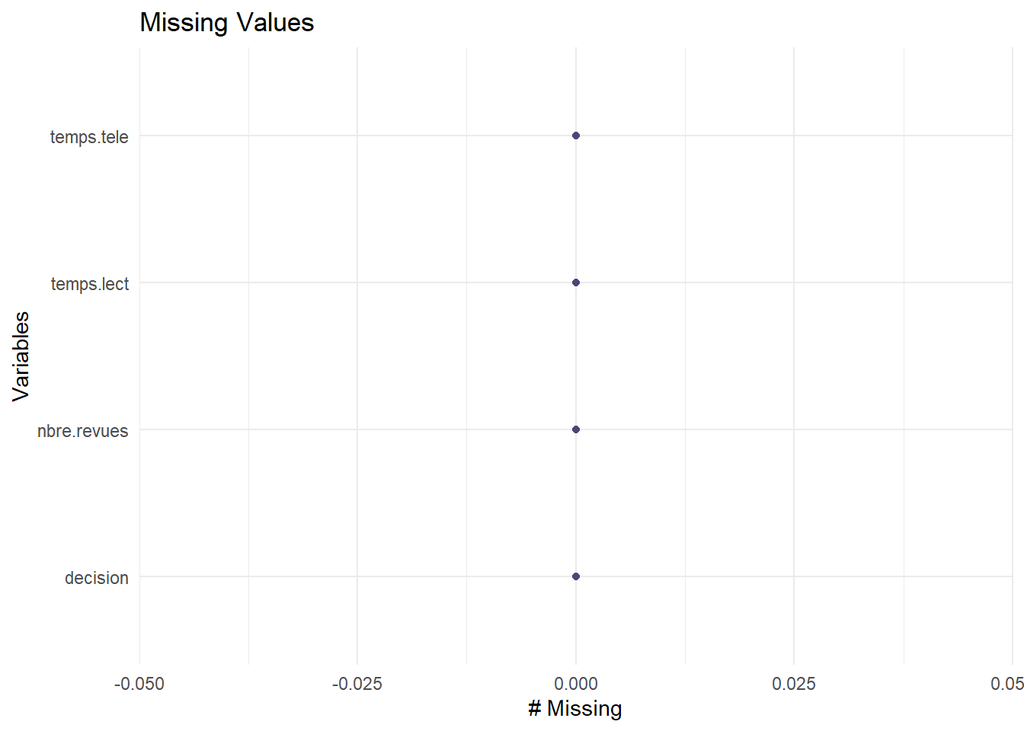

```r
# Visualize missing values
gg_miss_var(Abonnements) + ggtitle("Missing Values")
```

```r
# Produce result summaries
Summary <- data.frame(mean = sapply(Abonnements[,c(1:4)], mean,na.rm = T)
                ,median = sapply(Abonnements[,c(1:4)], median,na.rm = T)
                ,min = sapply(Abonnements[,c(1:4)], min,na.rm = T)
                ,max = sapply(Abonnements[,c(1:4)], max,na.rm = T)
                ,sd = sapply(Abonnements[,c(1:4)], sd,na.rm = T))
colnames(Summary) = c("Mean","Median","Min","Max","Standard Deviation")

 # Use kable to design table
kable(head(Summary)) %>% kable_classic() %>%
  kableExtra::kable_styling(bootstrap_options = c("striped", "hover", "condensed","responsive")) %>%
  kable_styling(position = "center")
```

|  | Mean | Median | Min | Max | Standard Deviation |
| --- | --- | --- | --- | --- | --- |
| decision | 0.5666667 | 1.0 | 0 | 1 | 0.4997174 |
| temps.lect | 34.4000000 | 30.0 | 1 | 120 | 29.7744060 |
| temps.tele | 43.5083333 | 50.0 | 0 | 100 | 27.3115254 |
| nbre.revues | 3.5000000 | 3.5 | 1 | 6 | 1.7222374 |

To kick off this Abonnement exercise, the reader must explore the dataset. Therefore, we will take a quick peak at what it contains. There are 60 observations with four variables. Those variables include ‘decision,’ ‘temps.lect,’ ‘temps.tele,’ and ‘nbre.revues.’ The only variable that is not an integer is ‘temps.tele’ which is numeric. Within the missing values analysis, it is noticed there are no NAs present. Last but not least, the summary table shows the breakout for each variable. It is important to note that ‘decision’ is binary and therefore, it only has values 0 or 1 which aligns to the data details given for this assignment.

### 1.1 Univariate Descriptive Analysis

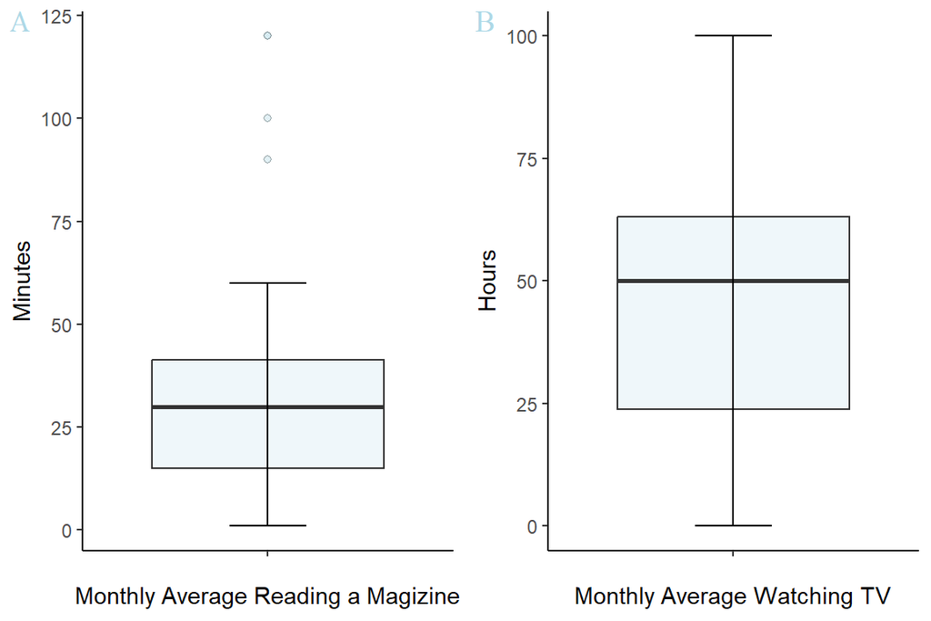

```r
# Using ggplot to create various boxplots for discrete variables
temps.lect.box <- ggplot(data = Abonnements, aes(x="",y= temps.lect)) +
    geom_boxplot(fill="lightblue", alpha=0.2, outlier.shape = 21, outlier.color = "black") +
    stat_boxplot(geom='errorbar', linetype=1, width=0.25) +
    ylab("Minutes") + # Label names
    xlab("Monthly Average Reading a Magizine") + # Label names
    theme_classic() # A classic theme, no grid lines

temps.tele.box <- ggplot(data = Abonnements, aes(x="",y= temps.tele)) +
    geom_boxplot(fill="lightblue", alpha=0.2, outlier.shape = 21, outlier.color = "black") +
    stat_boxplot(geom='errorbar', linetype=1, width=0.25) +
    ylab("Hours") + # Label names
    xlab("Monthly Average Watching TV") + # Label names
    theme_classic() # A classic theme, no grid lines

# Places the graphs into one space
plot_grid(temps.lect.box, temps.tele.box, labels = "AUTO",
  label_fontfamily = "serif",
  label_fontface = "plain",
  label_colour = "lightblue")
```

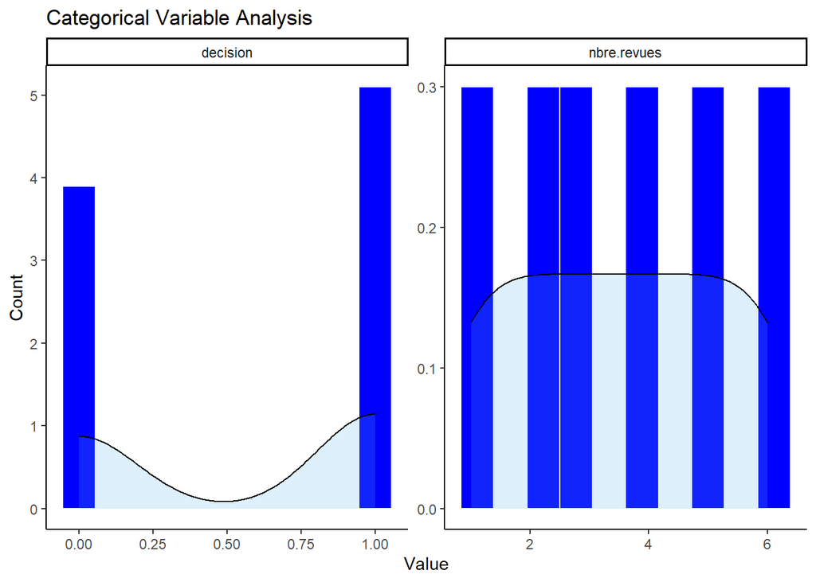

```r
# Only include categorical variables
Abonnements_categorical <- Abonnements[c(1,4)]

histograms <- ggplot(gather(data = Abonnements_categorical),aes(value)) +
  geom_histogram(aes(y=..density..),bins = 10, color = "white", fill = "blue") + # Creates bin sizing and sets the lines as white
  geom_density(alpha= .2, fill="#56B4E9") +
  facet_wrap(~key,scales = "free") + # Converting the graphs into panels
  ggtitle("Categorical Variable Analysis") + # Title name
  ylab("Count") + xlab("Value") + # Label names
  theme_classic() # A classic theme, with x and y axis lines and no grid lines

# Display the histrograms
histograms
```

Throughout the univariate analysis, we break the variables into two groups: continuous and categorical. The boxplots show ‘temps.lect’ and ‘temps.tele’ because they can assume an infinite number of real values within a given interval. The summary table above helps show the actual values that can be seen within these two charts. For ‘temps.lect,’ there are three outliers that exceed the third quantile. At the moment, it is too early to say if these points will have an influence on our model. Additionally, we see that ‘temps.tele’ is skewed left (negative), but appears to be normally distributed. In the second set of graphs, we use barplots to show ‘decision’ and ‘nbre.revues.’ There are two choices for ‘decision,’ and most have choose to continue. For the number of magazines that a person has already subscribed to, it can be seen that the same amount of people subscribe to the same number of magazines which range from 1 to 6.

### 1.2 Multivariate Descriptive Analysis

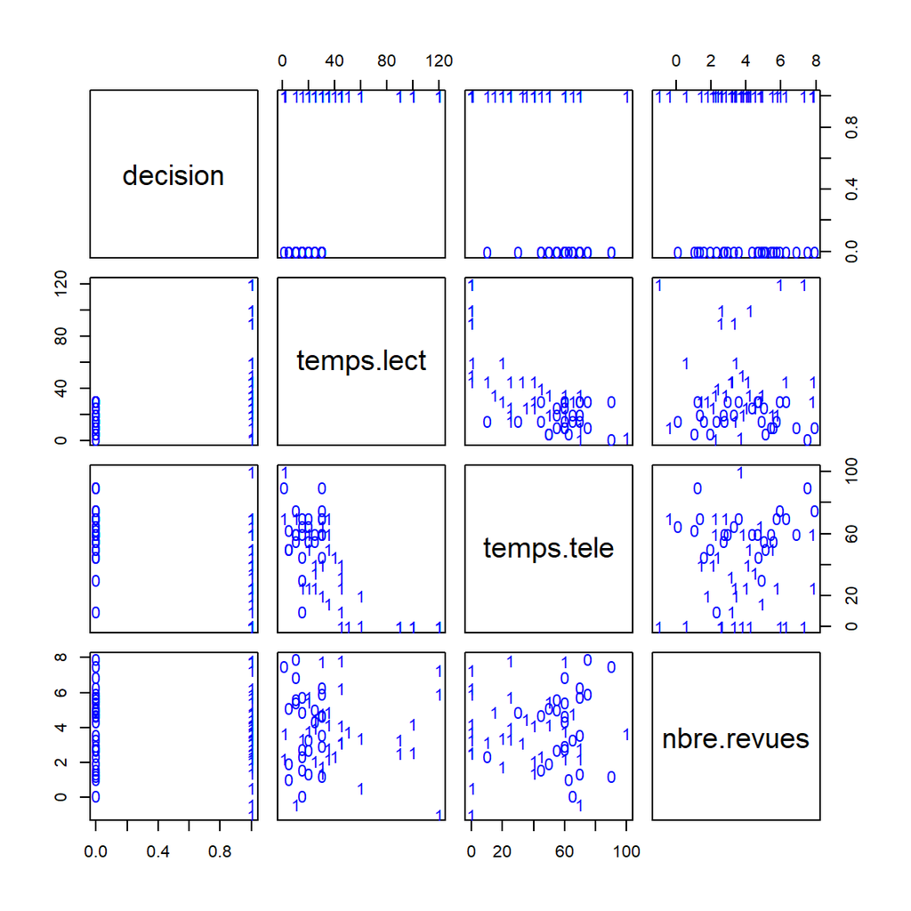

```r
# Original data set and all its columns
Abonnements.jit = Abonnements

# Used to add noise to the numeric vector
Abonnements.jit[,4] = jitter(Abonnements[,4], 2, factor = 2)

# Y (decision) is the response variable
label = as.character(Abonnements[,1])

# Shows the levels for each observation on the scatterplot
PairsLab(Abonnements.jit, label)
```

```r
cormat <- round(cor(Abonnements),2) # Round the correlation coefficient to two decimal places

melted_cormat <- melt(cormat) # One way to reshape and elongate the data frame

# Get upper triangle of the correlation matrix
  get_upper_tri <- function(cormat){
    cormat[lower.tri(cormat)]<- NA
    return(cormat)
  }

# Rename the correlation coefficient value
upper_tri <- get_upper_tri(cormat)
upper_tri
```

```
##             decision temps.lect temps.tele nbre.revues
## decision           1       0.49      -0.53       -0.10
## temps.lect        NA       1.00      -0.72        0.08
## temps.tele        NA         NA       1.00       -0.02
## nbre.revues       NA         NA         NA        1.00
```

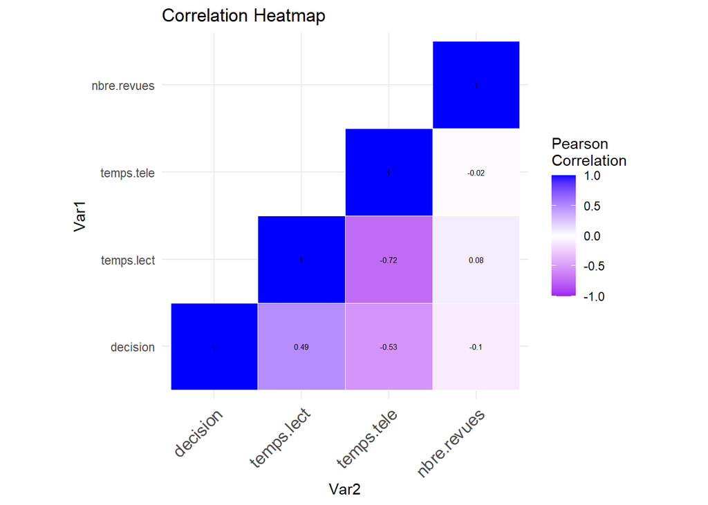

```r
# Use correlation between variables as distance
reorder_cormat <- function(cormat){
dd <- as.dist((1-cormat)/2)
hc <- hclust(dd)
cormat <-cormat[hc$order, hc$order]
}

# Reorder the correlation matrix
cormat <- reorder_cormat(cormat)
upper_tri <- get_upper_tri(cormat)

# Melt the correlation matrix
melted_cormat <- melt(upper_tri, na.rm = TRUE)

# Create a ggheatmap with multiple characteristics
ggheatmap <- ggplot(melted_cormat, aes(Var2, Var1, fill = value)) +
  geom_tile(color = "white") +
  scale_fill_gradient2(low = "purple", high = "blue", mid = "white", midpoint = 0, limit = c(-1,1), space = "Lab", name="Pearson\nCorrelation") +
  ggtitle("Correlation Heatmap") + # Title name
  theme_minimal() + # Minimal theme, keeps in the lines
  theme(axis.text.x = element_text(angle = 45, vjust = 1, size = 12, hjust = 1)) +
  coord_fixed() +
  geom_text(aes(Var2, Var1, label = value), color = "black", size = 2)

# Print the heat map
print(ggheatmap)
```

To give a better representation of the data, we can review the Heatmap. It can be seen that there is a higher negative relationship between ‘temps.lect’ and ‘temps.tele’ at -0.72. Additionally, it is fascinating to see that when comparing ‘decision’ to other variables, it has a positive relationship with ‘temps.lect’ but not with ‘temps.tele.’

**Code Resources:** https://r-graph-gallery.com/199-correlation-matrix-with-ggally.html and http://www.sthda.com/english/wiki/ggplot2-quick-correlation-matrix-heatmap-r-software-and-data-visualization

## **2 Classical Logistic Regression**

### 2.1 | 2.2 Parameter Estimation, Deviance Analysis, Goodness-of-Fit, and Residual Analysis

```r
# Run the glm as it performs the estimation for a classical logistic regression
Abonnements.glm = glm(decision ~ ., family = binomial(link = "logit"), data = Abonnements)

# Review the logistics summary output
summary(Abonnements.glm)
```

```
##
## Call:
## glm(formula = decision ~ ., family = binomial(link = "logit"),
##     data = Abonnements)
##
## Deviance Residuals:
##      Min        1Q    Median        3Q       Max
## -1.66104  -0.84436   0.04373   0.76258   2.43629
##
## Coefficients:
##             Estimate Std. Error z value Pr(>|z|)
## (Intercept)  0.50836    1.50813   0.337   0.7361
## temps.lect   0.07124    0.03148   2.263   0.0236 *
## temps.tele  -0.03239    0.01784  -1.815   0.0695 .
## nbre.revues -0.16359    0.20487  -0.798   0.4246
## ---
## Signif. codes:  0 '***' 0.001 '**' 0.01 '*' 0.05 '.' 0.1 ' ' 1
##
## (Dispersion parameter for binomial family taken to be 1)
##
##     Null deviance: 82.108  on 59  degrees of freedom
## Residual deviance: 54.870  on 56  degrees of freedom
## AIC: 62.87
##
## Number of Fisher Scoring iterations: 6
```

Within the logistic model, there are two variables (‘temps.tele’ and ‘nbre.revues’) that are not statistically significant since there p-values are higher than alpha = 0.05. When interpreting the coefficients, we can review the only variable that is significant, ‘temps.lect.’ A one unit increase in this predictor variable is associated with an average change of 0.07124 in the log odds of the response variable am taking on a value of 1. Before moving forward with the analysis though, it is critical to check the residuals to see if there are any patterns that an analyst would not approve.

*Additional Information*:

- The null deviance in the output tells us how well the response variable can be predicted by a model with only an intercept term.
- The residual deviance tells us how well the response variable can be predicted by the specific model that we fit with p predictor variables. The lower the value, the better the model is able to predict the value of the response variable.
- The Akaike information criterion (AIC) is a metric that is used to compare the fit of different regression models. The lower the value, the better the regression model is able to fit the data.

**Resource**: https://www.statology.org/interpret-glm-output-in-r/

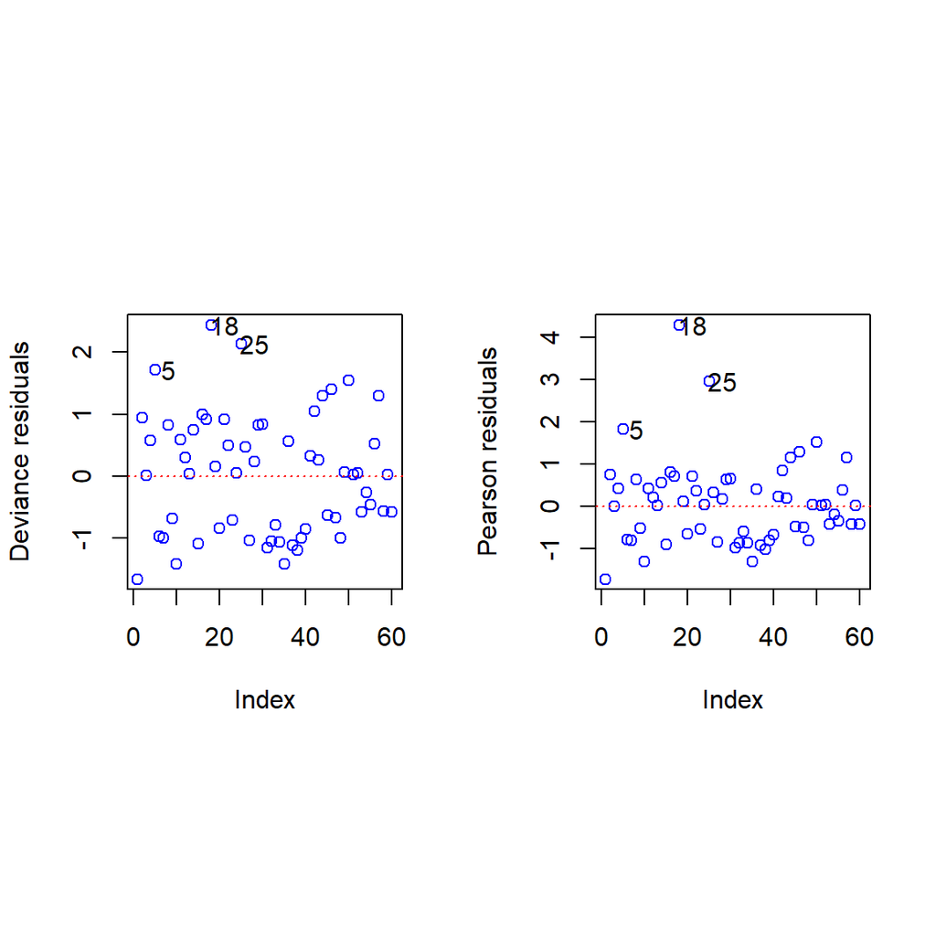

```r
# Plot the residuals
PlotResidLogist(Abonnements.glm)
```

Residuals can be defined in several ways. The first is through the deviance residuals which is the contribution of each observation to the total. The second one is the Pearson residuals which is a measure of adequacy of the model. According to slide 532, a residual will be considered large if its absolute value exceeds (approximately) 2. Therefore, we can see that there is a problem within both of these charts. To the left, points 18 and 25 exceed 2. The same issue is seen in the Pearson analysis. For the moment, we can try to remove these two observations and look at the model again.

```r
# Outlier removal
Abonnements_outlier = Abonnements[-c(18,25),]

# Run the glm as it performs the estimation for a classical logistic regression
Abonnements.glm2 = glm(decision ~ ., family = binomial(link = "logit"), data = Abonnements_outlier)

# Review the logistics summary output
summary(Abonnements.glm2)
```

```
##
## Call:
## glm(formula = decision ~ ., family = binomial(link = "logit"),
##     data = Abonnements_outlier)
##
## Deviance Residuals:
##      Min        1Q    Median        3Q       Max
## -1.64832  -0.50745   0.00071   0.38201   2.63101
##
## Coefficients:
##              Estimate Std. Error z value Pr(>|z|)
## (Intercept) -0.541033   1.761000  -0.307  0.75867
## temps.lect   0.147872   0.054178   2.729  0.00635 **
## temps.tele  -0.062271   0.024346  -2.558  0.01053 *
## nbre.revues -0.007889   0.258752  -0.030  0.97568
## ---
## Signif. codes:  0 '***' 0.001 '**' 0.01 '*' 0.05 '.' 0.1 ' ' 1
##
## (Dispersion parameter for binomial family taken to be 1)
##
##     Null deviance: 79.783  on 57  degrees of freedom
## Residual deviance: 39.826  on 54  degrees of freedom
## AIC: 47.826
##
## Number of Fisher Scoring iterations: 7
```

By removing points 18 and 25, there are now two variables that are statistically significant, ‘temps.lect’ and ‘temps.tele’ since their p-values do not exceed 0.05. We will review the residuals once again to see if any points exceed the 2 threshold.

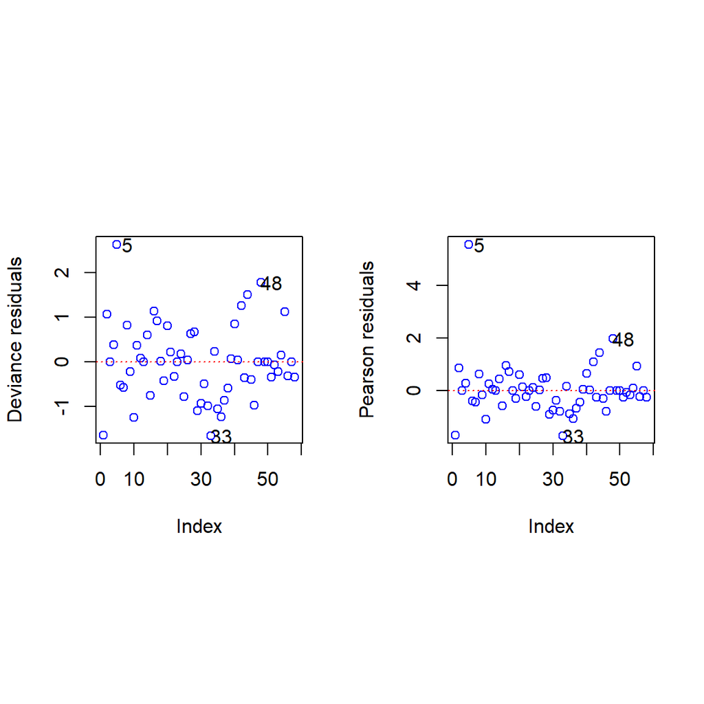

```r
# Plot the residuals
PlotResidLogist(Abonnements.glm2)
```

If you recall from the previous residual analysis, point 5 was very close to exceeding 2. After removing the last two points, 5 now meets that criteria to possibly be removed. Since it was not over the threshold before, we will not delete it. As in TPs 5 and 6, we must check that these residuals are assuming:  
1. There should be a similar variability about the X-axis at all points, around 0 on the Y -axis  
2. Check the relationship or patterns  
3. Check the normality of the errors

It would appear that there are no issues!

```r
# Perform ANOVA test to estimate how a quantitative dependent variable changes according to the levels of one or more categorical independent variables
anova(Abonnements.glm2, test = "Chisq")
```

```
## Analysis of Deviance Table
##
## Model: binomial, link: logit
##
## Response: decision
##
## Terms added sequentially (first to last)
##
##
##             Df Deviance Resid. Df Resid. Dev  Pr(>Chi)
## NULL                           57     79.783
## temps.lect   1  30.9018        56     48.881 2.714e-08 ***
## temps.tele   1   9.0548        55     39.827   0.00262 **
## nbre.revues  1   0.0009        54     39.826   0.97569
## ---
## Signif. codes:  0 '***' 0.001 '**' 0.01 '*' 0.05 '.' 0.1 ' ' 1
```

The anova() function is helpful to see how the model progresses as more variables are added. For instance, there are four ‘levels’ within the output above since the dataset has that many variables. In each row, it shows important metrics such as deviance, degrees of freedom, and p-value. If we break out each row, it would contain these variables:

- Row 1 (NULL): Model only includes the intercept (no p-value)
- Row 2: (‘temps.lect’): Model includes the intercept and ‘temps.lect’ (p-value < 0.05)
- Row 3: (‘temps.tele’): Model includes the intercept, ‘temps.lect,’ and ‘temps.tele’ (p-value < 0.05)
- Row 4: (‘nbre.revues’): Model includes the intercept, ‘temps.lect,’ ‘temps.tele’ and ‘nbre.revues’ (p-value > 0.05)

‘nbre.revues’ continues to not be significant. Additionally, the deviance represents the (log)-likelihood of the ‘saturated model’ with the likelihood of the ‘applied’ model under Ho. It can be seen that between the third and fourth row that those variables are very close (0.0009). This could potentially mean that one of those could be removed. It is likely to be ‘nbre.revues’ since its p-value exceeds 0.05.

To choose the best model, we removed the two outliers and ‘nbre.revues’ to see how well these assumptions would work compared of we kept everything the same like the first glm model. The goal is to rerun the classical logistic regression to hopefully get the best fitting model!

```r
# Run the glm as it performs the estimation for a classical logistic regression
Abonnements.glm3 = glm(decision ~ temps.lect + temps.tele, family = binomial(link = "logit"), data = Abonnements_outlier)

# Review the logistics summary output
summary(Abonnements.glm3)
```

```
##
## Call:
## glm(formula = decision ~ temps.lect + temps.tele, family = binomial(link = "logit"),
##     data = Abonnements_outlier)
##
## Deviance Residuals:
##     Min       1Q   Median       3Q      Max
## -1.6520  -0.5034   0.0007   0.3839   2.6405
##
## Coefficients:
##             Estimate Std. Error z value Pr(>|z|)
## (Intercept) -0.56705    1.53987  -0.368  0.71269
## temps.lect   0.14819    0.05322   2.784  0.00537 **
## temps.tele  -0.06243    0.02385  -2.618  0.00885 **
## ---
## Signif. codes:  0 '***' 0.001 '**' 0.01 '*' 0.05 '.' 0.1 ' ' 1
##
## (Dispersion parameter for binomial family taken to be 1)
##
##     Null deviance: 79.783  on 57  degrees of freedom
## Residual deviance: 39.827  on 55  degrees of freedom
## AIC: 45.827
##
## Number of Fisher Scoring iterations: 7
```

```r
# Perform ANOVA test to estimate how a quantitative dependent variable changes according to the levels of one or more categorical independent variables
anova(Abonnements.glm2, Abonnements.glm3, test="Chisq")
```

```
## Analysis of Deviance Table
##
## Model 1: decision ~ temps.lect + temps.tele + nbre.revues
## Model 2: decision ~ temps.lect + temps.tele
##   Resid. Df Resid. Dev Df    Deviance Pr(>Chi)
## 1        54     39.826
## 2        55     39.827 -1 -0.00092888   0.9757
```

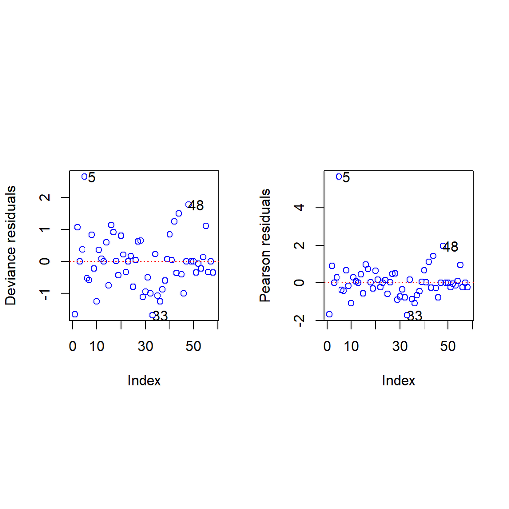

```r
# Plot the residuals
PlotResidLogist(Abonnements.glm3)
```

```r
# Goodness-of-fit results
HosLem.test(Abonnements_outlier$decision, fitted(Abonnements.glm3))
```

```
##
##  Hosmer-Lemeshow goodness of fit test
##
## data:  Abonnements_outlier$decision, fitted(Abonnements.glm3)
## X-squared = 8.7276, df = 8, p-value = 0.3658
```

The last part of the classical logistic regression is to check the goodness-of-fit. Since the p-value is above alpha (0.05), this indicates that there is no evidence of the model being of poor fit. The model that only includes ‘temps.lect’ and ‘temps.tele’ is the best and most simplistic for this dataset.

## **3 Robust Logistic Regression**

### 3.1 Parameter estimation and goodness of fit

```r
# Run the glmRob as it performs the estimation for a robust logistic regression
Abonnements.glmRob = glmrob(decision ~ temps.lect + temps.tele, family = binomial(link = "logit"), data = Abonnements)

# Review the logistics summary output
summary(Abonnements.glmRob)
```

```
##
## Call:  glmrob(formula = decision ~ temps.lect + temps.tele, family = binomial(link = "logit"),      data = Abonnements)
##
##
## Coefficients:
##             Estimate Std. Error z value Pr(>|z|)
## (Intercept) -0.45949    1.57079  -0.293   0.7699
## temps.lect   0.13783    0.05602   2.460   0.0139 *
## temps.tele  -0.06033    0.02459  -2.454   0.0141 *
## ---
## Signif. codes:  0 '***' 0.001 '**' 0.01 '*' 0.05 '.' 0.1 ' ' 1
## Robustness weights w.r * w.x:
##  53 weights are ~= 1. The remaining 7 ones are
##       1       5      18      25      35      46      50
## 0.81390 0.25772 0.06007 0.13861 0.83211 0.93857 0.69415
##
## Number of observations: 60
## Fitted by method 'Mqle'  (in 16 iterations)
##
## (Dispersion parameter for binomial family taken to be 1)
##
## No deviance values available
## Algorithmic parameters:
##    acc    tcc
## 0.0001 1.3450
## maxit
##    50
## test.acc
##   "coef"
```

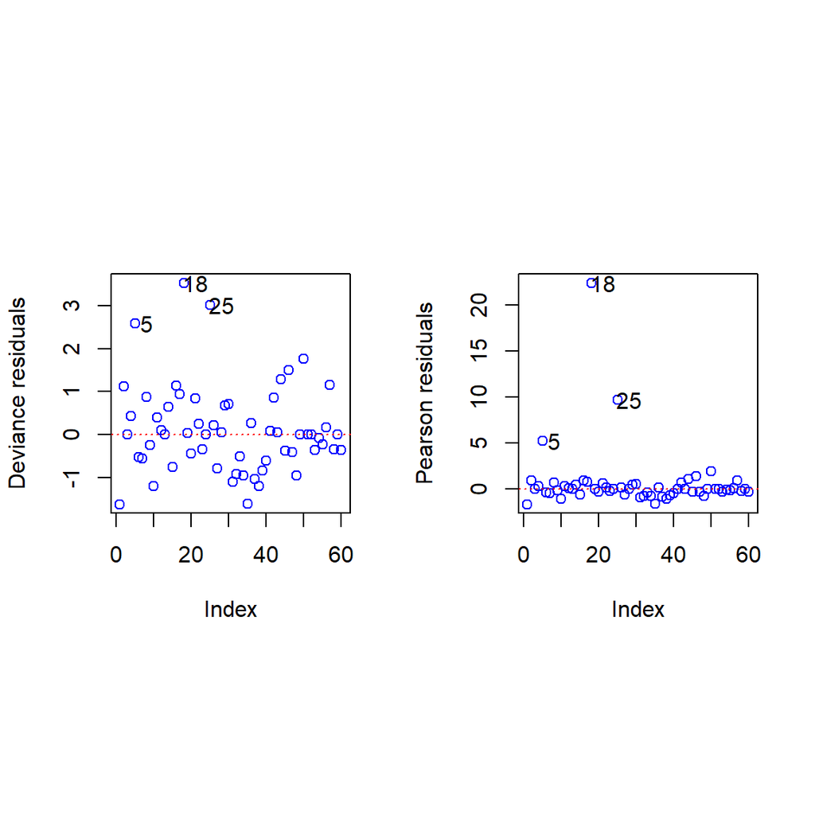

```r
# Plot the residuals
PlotResidLogistRob(Abonnements.glmRob)
```

```r
# Goodness-of-fit results
HosLem.test(Abonnements$decision, fitted(Abonnements.glmRob))
```

```
##
##  Hosmer-Lemeshow goodness of fit test
##
## data:  Abonnements$decision, fitted(Abonnements.glmRob)
## X-squared = 86.32, df = 8, p-value = 2.554e-15
```

## **Conclusion**

I would inform the commercial director that the most influential factors are ‘temps.lect’ and ‘temps.tele.’ To calculate the impact of both of these variables, review the latest summary for the robust model. The robust model will be the best method due to the numerous extreme values that are observed. After reviewing the coefficients…

Good luck to the director!

## **1 Exploratory Data Analysis**

```r
# Get or set the dimension of the specified matrix, array or data frame
dim(Ronflement)
```

```
## [1] 100   7
```

```r
 # Use kable to design table
kable(head(Ronflement)) %>% kable_classic() %>%
  kableExtra::kable_styling(bootstrap_options = c("striped", "hover", "condensed","responsive")) %>%
  kable_styling(position = "center")
```

| age | poids | taille | alcool | sexe | tabac | ronfle |
| --- | --- | --- | --- | --- | --- | --- |
| 49 | 51.1 | 157.6 | 0 | 0 | 0 | 0 |
| 38 | 76.8 | 161.2 | 0 | 1 | 0 | 0 |
| 40 | 104.5 | 180.0 | 5 | 0 | 1 | 0 |
| 33 | 64.7 | 177.9 | 0 | 1 | 1 | 0 |
| 58 | 124.8 | 197.0 | 0 | 0 | 0 | 1 |
| 41 | 81.5 | 167.9 | 0 | 0 | 1 | 0 |

```r
# Compactly displaying the internal structure of a R object
str(Ronflement)
```

```
## 'data.frame':    100 obs. of  7 variables:
##  $ age   : int  49 38 40 33 58 41 63 68 61 70 ...
##  $ poids : num  51.1 76.8 104.5 64.7 124.8 ...
##  $ taille: num  158 161 180 178 197 ...
##  $ alcool: int  0 0 5 0 0 0 0 4 7 3 ...
##  $ sexe  : int  0 1 0 1 0 0 1 0 0 0 ...
##  $ tabac : int  0 0 1 1 0 1 1 0 1 1 ...
##  $ ronfle: int  0 0 0 0 1 0 0 1 0 0 ...
```

```r
# Function returns the positions with missing values
which(is.na(Ronflement))
```

```
## integer(0)
```

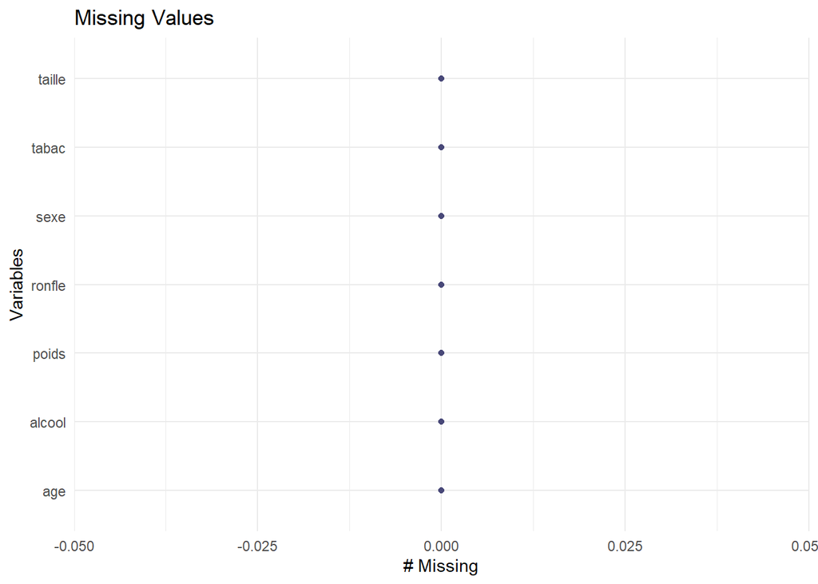

```r
# Visualize missing values
gg_miss_var(Ronflement) + ggtitle("Missing Values")
```

```r
# Produce result summaries
Summary <- data.frame(mean = sapply(Ronflement[,c(1:4)], mean,na.rm = T)
                ,median = sapply(Ronflement[,c(1:4)], median,na.rm = T)
                ,min = sapply(Ronflement[,c(1:4)], min,na.rm = T)
                ,max = sapply(Ronflement[,c(1:4)], max,na.rm = T)
                ,sd = sapply(Ronflement[,c(1:4)], sd,na.rm = T))
colnames(Summary) = c("Mean","Median","Min","Max","Standard Deviation")

 # Use kable to design table
kable(head(Summary)) %>% kable_classic() %>%
  kableExtra::kable_styling(bootstrap_options = c("striped", "hover", "condensed","responsive")) %>%
  kable_styling(position = "center")
```

|  | Mean | Median | Min | Max | Standard Deviation |
| --- | --- | --- | --- | --- | --- |
| age | 52.270 | 52.00 | 23.0 | 74.0 | 11.397195 |
| poids | 96.642 | 92.85 | 50.1 | 171.0 | 30.963361 |
| taille | 181.404 | 181.80 | 149.2 | 210.2 | 16.057610 |
| alcool | 2.950 | 2.00 | 0.0 | 15.0 | 3.364626 |

To kick off this Ronflement exercise, the reader must explore the dataset. Therefore, we will take a quick peak at what it contains. There are 100 observations with seven variables. Those variables include ‘age,’ ‘poids,’ ‘taille,’ alcool,’ sexe,’ tabac,’ and ‘ronfle.’ There are two types of variables: integer and numeric. Within the missing values analysis, it is noticed there are no NAs present. Last but not least, the summary table shows the breakout for each variable. It is important to note that there are three variables that are binary: ‘sexe,’ ‘tabac,’ and ‘ronfle.’ Therefore, it only has values 0 or 1 which aligns to the data details given for this assignment.

### 1.1 Univariate Descriptive Analysis

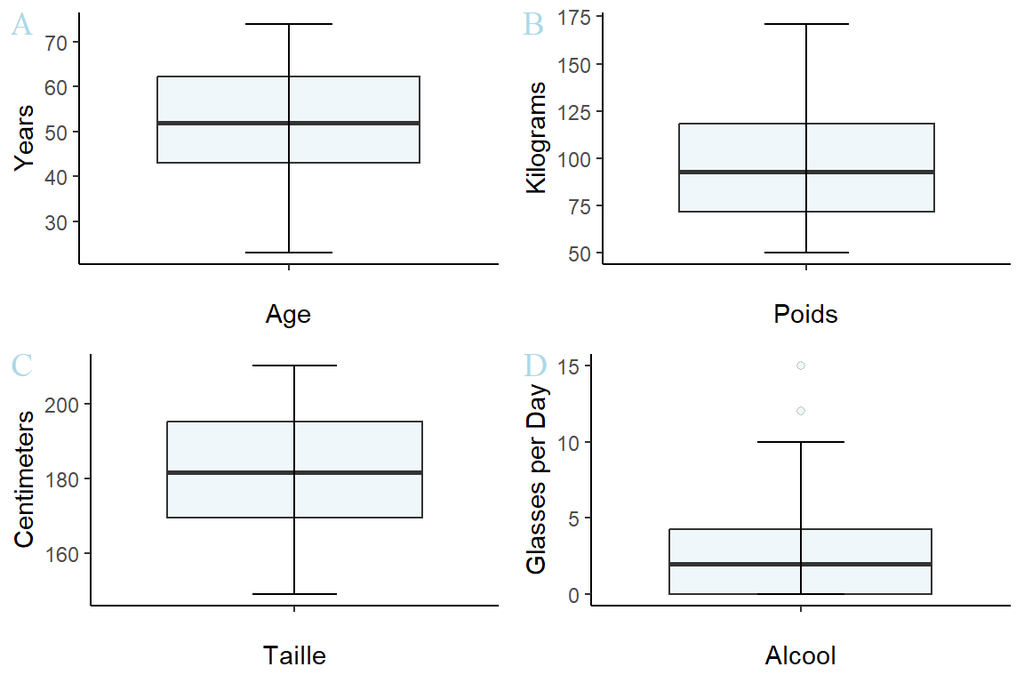

```r
# Using ggplot to create various boxplots for discrete variables
age.box <- ggplot(data = Ronflement, aes(x="",y= age)) +
    geom_boxplot(fill="lightblue", alpha=0.2, outlier.shape = 21, outlier.color = "black") +
    stat_boxplot(geom='errorbar', linetype=1, width=0.25) +
    ylab("Years") + # Label names
    xlab("Age") + # Label names
    theme_classic() # A classic theme, no grid lines

poids.box <- ggplot(data = Ronflement, aes(x="",y= poids)) +
    geom_boxplot(fill="lightblue", alpha=0.2, outlier.shape = 21, outlier.color = "black") +
    stat_boxplot(geom='errorbar', linetype=1, width=0.25) +
    ylab("Kilograms") + # Label names
    xlab("Poids") + # Label names
    theme_classic() # A classic theme, no grid lines

taille.box <- ggplot(data = Ronflement, aes(x="",y= taille)) +
    geom_boxplot(fill="lightblue", alpha=0.2, outlier.shape = 21, outlier.color = "black") +
    stat_boxplot(geom='errorbar', linetype=1, width=0.25) +
    ylab("Centimeters") + # Label names
    xlab("Taille") + # Label names
    theme_classic() # A classic theme, no grid lines

alcool.box <- ggplot(data = Ronflement, aes(x="",y= alcool)) +
    geom_boxplot(fill="lightblue", alpha=0.2, outlier.shape = 21, outlier.color = "black") +
    stat_boxplot(geom='errorbar', linetype=1, width=0.25) +
    ylab("Glasses per Day") + # Label names
    xlab("Alcool") + # Label names
    theme_classic() # A classic theme, no grid lines

# Places the graphs into one space
plot_grid(age.box, poids.box, taille.box, alcool.box, labels = "AUTO",
  label_fontfamily = "serif",
  label_fontface = "plain",
  label_colour = "lightblue")
```

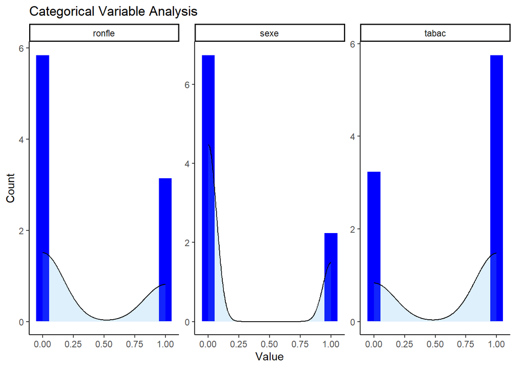

```r
# Only include categorical variables
Ronflement_categorical <- Ronflement[c(5:7)]

histograms <- ggplot(gather(data = Ronflement_categorical),aes(value)) +
  geom_histogram(aes(y=..density..),bins = 10, color = "white", fill = "blue") + # Creates bin sizing and sets the lines as white
  geom_density(alpha= .2, fill="#56B4E9") +
  facet_wrap(~key,scales = "free") + # Converting the graphs into panels
  ggtitle("Categorical Variable Analysis") + # Title name
  ylab("Count") + xlab("Value") + # Label names
  theme_classic() # A classic theme, with x and y axis lines and no grid lines

# Display the histrograms
histograms
```

### 1.2 Multivariate Descriptive Analysis

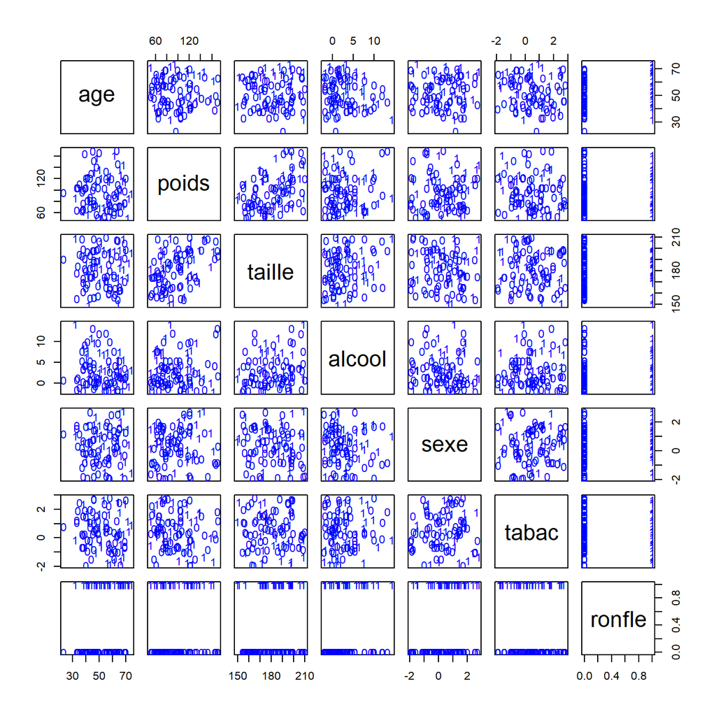

```r
# Original data set and all its columns
Ronflement.jit = Ronflement

# Used to add noise to the numeric vector
Ronflement.jit[,4] = jitter(Ronflement[,4], 2, factor = 2)
Ronflement.jit[,5] = jitter(Ronflement[,5], 2, factor = 2)
Ronflement.jit[,6] = jitter(Ronflement[,6], 2, factor = 2)

# Y (decision) is the response variable
label = as.character(Ronflement[,7])

# Shows the levels for each observation on the scatterplot
PairsLab(Ronflement.jit, label)
```

It can be immediately noticed that there are not groupings within the scatterplots. Therefore, transforming a variable is not necessary because ‘ronfle’ appears mixed for all quantitative variables.

```r
cormat <- round(cor(Ronflement),2) # Round the correlation coefficient to two decimal places

melted_cormat <- melt(cormat) # One way to reshape and elongate the data frame

# Get upper triangle of the correlation matrix
  get_upper_tri <- function(cormat){
    cormat[lower.tri(cormat)]<- NA
    return(cormat)
  }

# Rename the correlation coefficient value
upper_tri <- get_upper_tri(cormat)
upper_tri
```

```
##        age poids taille alcool  sexe tabac ronfle
## age      1 -0.02   0.01  -0.16 -0.04 -0.11   0.24
## poids   NA  1.00   0.42  -0.01  0.14 -0.14   0.04
## taille  NA    NA   1.00   0.13 -0.07  0.04   0.08
## alcool  NA    NA     NA   1.00 -0.45  0.34   0.24
## sexe    NA    NA     NA     NA  1.00 -0.29  -0.18
## tabac   NA    NA     NA     NA    NA  1.00  -0.10
## ronfle  NA    NA     NA     NA    NA    NA   1.00
```

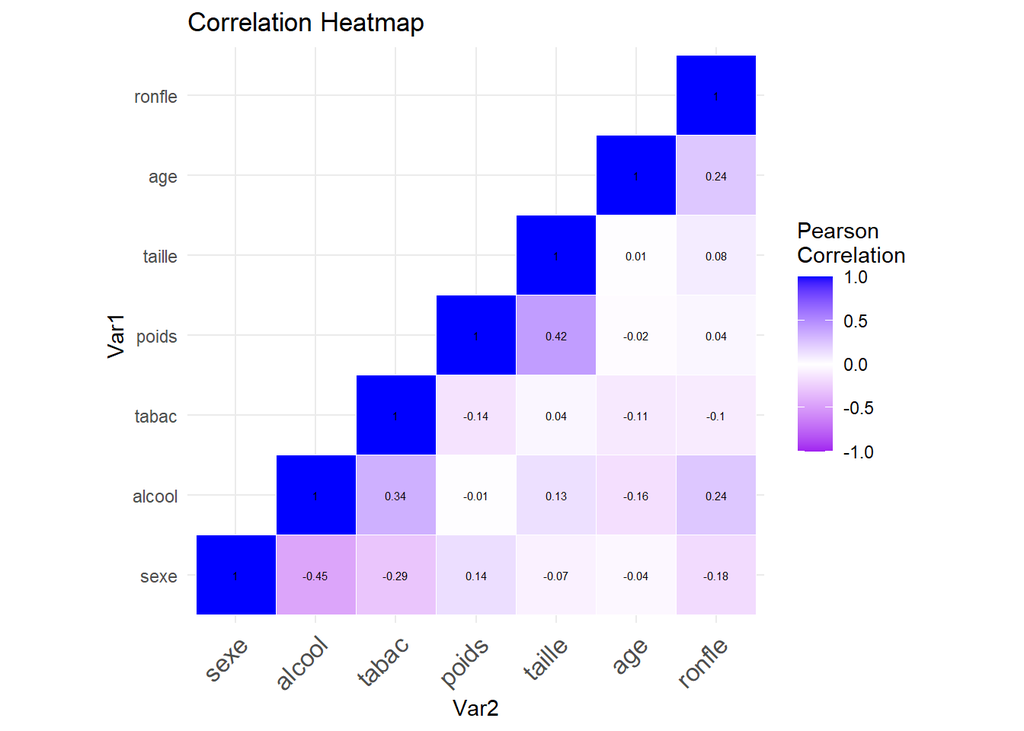

```r
# Use correlation between variables as distance
reorder_cormat <- function(cormat){
dd <- as.dist((1-cormat)/2)
hc <- hclust(dd)
cormat <-cormat[hc$order, hc$order]
}

# Reorder the correlation matrix
cormat <- reorder_cormat(cormat)
upper_tri <- get_upper_tri(cormat)

# Melt the correlation matrix
melted_cormat <- melt(upper_tri, na.rm = TRUE)

# Create a ggheatmap with multiple characteristics
ggheatmap <- ggplot(melted_cormat, aes(Var2, Var1, fill = value)) +
  geom_tile(color = "white") +
  scale_fill_gradient2(low = "purple", high = "blue", mid = "white", midpoint = 0, limit = c(-1,1), space = "Lab", name="Pearson\nCorrelation") +
  ggtitle("Correlation Heatmap") + # Title name
  theme_minimal() + # Minimal theme, keeps in the lines
  theme(axis.text.x = element_text(angle = 45, vjust = 1, size = 12, hjust = 1)) +
  coord_fixed() +
  geom_text(aes(Var2, Var1, label = value), color = "black", size = 2)

# Print the heat map
print(ggheatmap)
```

To give a better representation of the data, we can review the Heatmap. It can be seen that none of the variables have a strong positive or negative correlation to one another.

**Code Resources:** https://r-graph-gallery.com/199-correlation-matrix-with-ggally.html and http://www.sthda.com/english/wiki/ggplot2-quick-correlation-matrix-heatmap-r-software-and-data-visualization

## **2 Classical Logistic Regression**

### 2.1 | 2.2 Parameter Estimation, Deviance Analysis, Goodness-of-Fit, and Residual Analysis

```r
# Run the glm as it performs the estimation for a classical logistic regression
Ronflement.glm = glm(ronfle ~ ., family = binomial(link = "logit"), data = Ronflement)

# Review the logistics summary output
summary(Ronflement.glm)
```

```
##
## Call:
## glm(formula = ronfle ~ ., family = binomial(link = "logit"),
##     data = Ronflement)
##
## Deviance Residuals:
##     Min       1Q   Median       3Q      Max
## -1.5300  -0.8718  -0.5182   1.0411   2.2886
##
## Coefficients:
##              Estimate Std. Error z value Pr(>|z|)
## (Intercept) -5.168850   3.012593  -1.716  0.08621 .
## age          0.062702   0.023231   2.699  0.00695 **
## poids        0.001810   0.008523   0.212  0.83181
## taille       0.006336   0.016150   0.392  0.69483
## alcool       0.228502   0.085534   2.671  0.00755 **
## sexe        -0.675357   0.686465  -0.984  0.32520
## tabac       -1.157345   0.557420  -2.076  0.03787 *
## ---
## Signif. codes:  0 '***' 0.001 '**' 0.01 '*' 0.05 '.' 0.1 ' ' 1
##
## (Dispersion parameter for binomial family taken to be 1)
##
##     Null deviance: 129.49  on 99  degrees of freedom
## Residual deviance: 109.38  on 93  degrees of freedom
## AIC: 123.38
##
## Number of Fisher Scoring iterations: 4
```

Within the logistic model, there are three variables (‘age’ ‘alcool,’ and ‘tabac’) that are statistically significant since there p-values are less than alpha = 0.05. When interpreting the coefficients, we can say that one unit increase in this predictor variable is associated with an average change of 0.062702 (‘age’) in the log odds of the response variable am taking on a value of 1. Before moving forward with the analysis though, it is critical to check the residuals to see if there are any patterns that an analyst would want to avoid.

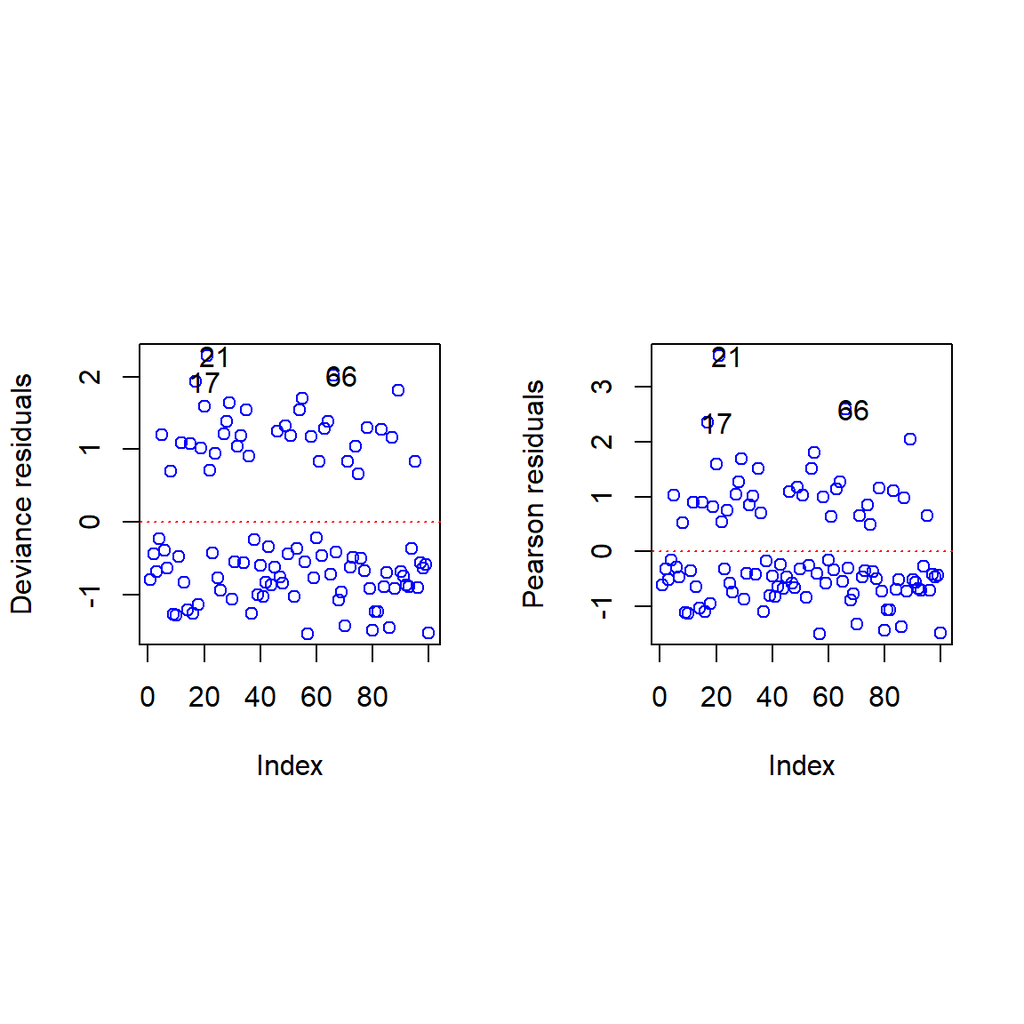

```r
# Plot the residuals
PlotResidLogist(Ronflement.glm)
```

Residuals can be defined in several ways. The first is through the deviance residuals which is the contribution of each observation to the total. The second one is the Pearson residuals which is a measure of adequacy of the model. According to slide 532, a residual will be considered large if its absolute value exceeds (approximately) 2. Therefore, we can see that there is a problem within both of these charts. To the left, point 21 exceeds 2. The same issue is seen in the Pearson analysis. For the moment, we can try to remove this observation and look at the model again.

```r
# Outlier removal
Ronflement_outlier = Ronflement[-c(21),]

# Run the glm as it performs the estimation for a classical logistic regression
Ronflement.glm2 = glm(ronfle ~ ., family = binomial(link = "logit"), data = Ronflement_outlier)

# Review the logistics summary output
summary(Ronflement.glm2)
```

```
##
## Call:
## glm(formula = ronfle ~ ., family = binomial(link = "logit"),
##     data = Ronflement_outlier)
##
## Deviance Residuals:
##     Min       1Q   Median       3Q      Max
## -1.5624  -0.8458  -0.4496   1.0022   2.1319
##
## Coefficients:
##              Estimate Std. Error z value Pr(>|z|)
## (Intercept) -5.573494   3.131621  -1.780  0.07512 .
## age          0.068145   0.024345   2.799  0.00512 **
## poids       -0.002102   0.008843  -0.238  0.81215
## taille       0.009583   0.016696   0.574  0.56599
## alcool       0.253286   0.089101   2.843  0.00447 **
## sexe        -0.988533   0.738058  -1.339  0.18045
## tabac       -1.465983   0.596476  -2.458  0.01398 *
## ---
## Signif. codes:  0 '***' 0.001 '**' 0.01 '*' 0.05 '.' 0.1 ' ' 1
##
## (Dispersion parameter for binomial family taken to be 1)
##
##     Null deviance: 127.37  on 98  degrees of freedom
## Residual deviance: 103.44  on 92  degrees of freedom
## AIC: 117.44
##
## Number of Fisher Scoring iterations: 5
```

The same three variables stay statistically significant.

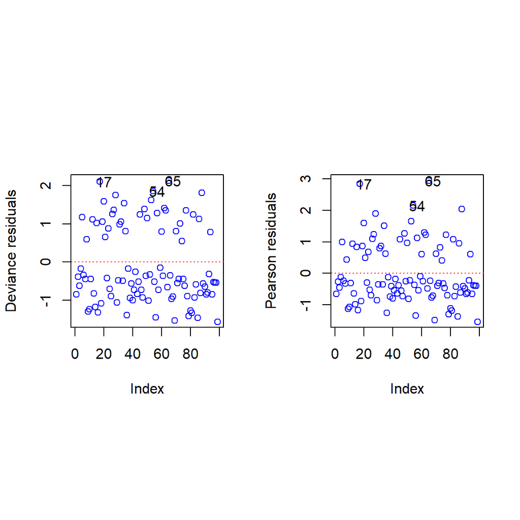

```r
# Plot the residuals
PlotResidLogist(Ronflement.glm2)
```

By removing point 21, there is no change within the model. At this point, we will leave it as is and check the residual assumptions:  
1. There should be a similar variability about the X-axis at all points, around 0 on the Y -axis  
2. Check the relationship or patterns  
3. Check the normality of the errors

It would appear that these criterion are satisfied. Due to this outcome of no change after extreme value removal, let’s take out the variable with the highest p-value, ‘poids.’

```r
anova(Ronflement.glm2, test="Chisq")
```

```
## Analysis of Deviance Table
##
## Model: binomial, link: logit
##
## Response: ronfle
##
## Terms added sequentially (first to last)
##
##
##        Df Deviance Resid. Df Resid. Dev Pr(>Chi)
## NULL                      98     127.37
## age     1   6.3224        97     121.05 0.011922 *
## poids   1   0.0343        96     121.01 0.853155
## taille  1   0.6595        95     120.36 0.416748
## alcool  1   9.4702        94     110.89 0.002088 **
## sexe    1   0.7910        93     110.09 0.373798
## tabac   1   6.6566        92     103.44 0.009879 **
## ---
## Signif. codes:  0 '***' 0.001 '**' 0.01 '*' 0.05 '.' 0.1 ' ' 1
```

Since ‘poids’ has a deviance near zero and has a p-value larger than alpha 0.05, we can remove ‘poids’ from the model that does not include point 21.

```r
# Run the glm as it performs the estimation for a classical logistic regression
Ronflement.glm3 = glm(ronfle ~ age + taille + alcool + sexe + tabac, family = binomial(link = "logit"), data = Ronflement_outlier)
```

```r
# Perform ANOVA test to estimate how a quantitative dependent variable changes according to the levels of one or more categorical independent variables
anova(Ronflement.glm2, Ronflement.glm3, test="Chisq")
```

```
## Analysis of Deviance Table
##
## Model 1: ronfle ~ age + poids + taille + alcool + sexe + tabac
## Model 2: ronfle ~ age + taille + alcool + sexe + tabac
##   Resid. Df Resid. Dev Df  Deviance Pr(>Chi)
## 1        92     103.44
## 2        93     103.49 -1 -0.056514   0.8121
```

The anova table confirms that ‘poids’ is not needed in the model since it has a small deviance and large p-large.

We need to review the anova model for glm3 to ensure that all variables are significant moving forward.

```r
# Perform ANOVA test to estimate how a quantitative dependent variable changes according to the levels of one or more categorical independent variables
anova(Ronflement.glm3, test="Chisq")
```

```
## Analysis of Deviance Table
##
## Model: binomial, link: logit
##
## Response: ronfle
##
## Terms added sequentially (first to last)
##
##
##        Df Deviance Resid. Df Resid. Dev Pr(>Chi)
## NULL                      98     127.37
## age     1   6.3224        97     121.05 0.011922 *
## taille  1   0.6538        96     120.39 0.418759
## alcool  1   9.5098        95     110.89 0.002044 **
## sexe    1   0.7595        94     110.12 0.383481
## tabac   1   6.6319        93     103.49 0.010017 *
## ---
## Signif. codes:  0 '***' 0.001 '**' 0.01 '*' 0.05 '.' 0.1 ' ' 1
```

The same issue occurs with ‘taille’ as we had with ‘poids.’ Looking at this variable before ‘sexe’ was due to the slightly larger p-value. Therefore, we will remove ‘taille’ from the model and check the anova output once again.

```r
# Run the glm as it performs the estimation for a classical logistic regression
Ronflement.glm4 = glm(ronfle ~ age + alcool + sexe + tabac, family = binomial(link = "logit"), data = Ronflement_outlier)

summary(Ronflement.glm4)
```

```
##
## Call:
## glm(formula = ronfle ~ age + alcool + sexe + tabac, family = binomial(link = "logit"),
##     data = Ronflement_outlier)
##
## Deviance Residuals:
##     Min       1Q   Median       3Q      Max
## -1.6332  -0.8472  -0.4597   1.0017   2.0040
##
## Coefficients:
##             Estimate Std. Error z value Pr(>|z|)
## (Intercept) -4.06099    1.49471  -2.717  0.00659 **
## age          0.06828    0.02428   2.813  0.00491 **
## alcool       0.25703    0.08859   2.901  0.00372 **
## sexe        -0.99308    0.72479  -1.370  0.17064
## tabac       -1.44139    0.58677  -2.457  0.01403 *
## ---
## Signif. codes:  0 '***' 0.001 '**' 0.01 '*' 0.05 '.' 0.1 ' ' 1
##
## (Dispersion parameter for binomial family taken to be 1)
##
##     Null deviance: 127.37  on 98  degrees of freedom
## Residual deviance: 103.77  on 94  degrees of freedom
## AIC: 113.77
##
## Number of Fisher Scoring iterations: 5
```

```r
anova(Ronflement.glm4, Ronflement.glm2, test="Chisq")
```

```
## Analysis of Deviance Table
##
## Model 1: ronfle ~ age + alcool + sexe + tabac
## Model 2: ronfle ~ age + poids + taille + alcool + sexe + tabac
##   Resid. Df Resid. Dev Df Deviance Pr(>Chi)
## 1        94     103.77
## 2        92     103.44  2  0.33197   0.8471
```

The large p-value and small deviance prove that we do not need ‘tailles’ or ‘poids’ without the model.

```r
anova(Ronflement.glm4,test="Chisq")
```

```
## Analysis of Deviance Table
##
## Model: binomial, link: logit
##
## Response: ronfle
##
## Terms added sequentially (first to last)
##
##
##        Df Deviance Resid. Df Resid. Dev Pr(>Chi)
## NULL                      98     127.37
## age     1   6.3224        97     121.05 0.011922 *
## alcool  1   9.9208        96     111.13 0.001634 **
## sexe    1   0.7321        95     110.40 0.392214
## tabac   1   6.6268        94     103.77 0.010046 *
## ---
## Signif. codes:  0 '***' 0.001 '**' 0.01 '*' 0.05 '.' 0.1 ' ' 1
```

Unforunately, the quest is not over. ‘Sexe’ may be causing an issue now since its p-value is high and it continues to be not signifigant in our model.

```r
# Run the glm as it performs the estimation for a classical logistic regression
Ronflement.glm5 = glm(ronfle ~ age + alcool + tabac, family = binomial(link = "logit"), data = Ronflement_outlier)

anova(Ronflement.glm5, Ronflement.glm2, test="Chisq")
```

```
## Analysis of Deviance Table
##
## Model 1: ronfle ~ age + alcool + tabac
## Model 2: ronfle ~ age + poids + taille + alcool + sexe + tabac
##   Resid. Df Resid. Dev Df Deviance Pr(>Chi)
## 1        95     105.78
## 2        92     103.44  3   2.3434   0.5043
```

```r
# Goodness-of-fit results
HosLem.test(Ronflement_outlier$ronfle, fitted(Ronflement.glm4))
```

```
##
##  Hosmer-Lemeshow goodness of fit test
##
## data:  Ronflement_outlier$ronfle, fitted(Ronflement.glm4)
## X-squared = 8.1127, df = 8, p-value = 0.4225
```

The last part of the classical logistic regression is to check the goodness-of-fit. Since the p-value is above alpha (0.05), this indicates that there is no evidence of the model being of poor fit. The model that only includes ‘age,’ ‘alcool,’ ‘tabac,’ and ‘sexe’ is the best and most simplistic for this dataset.

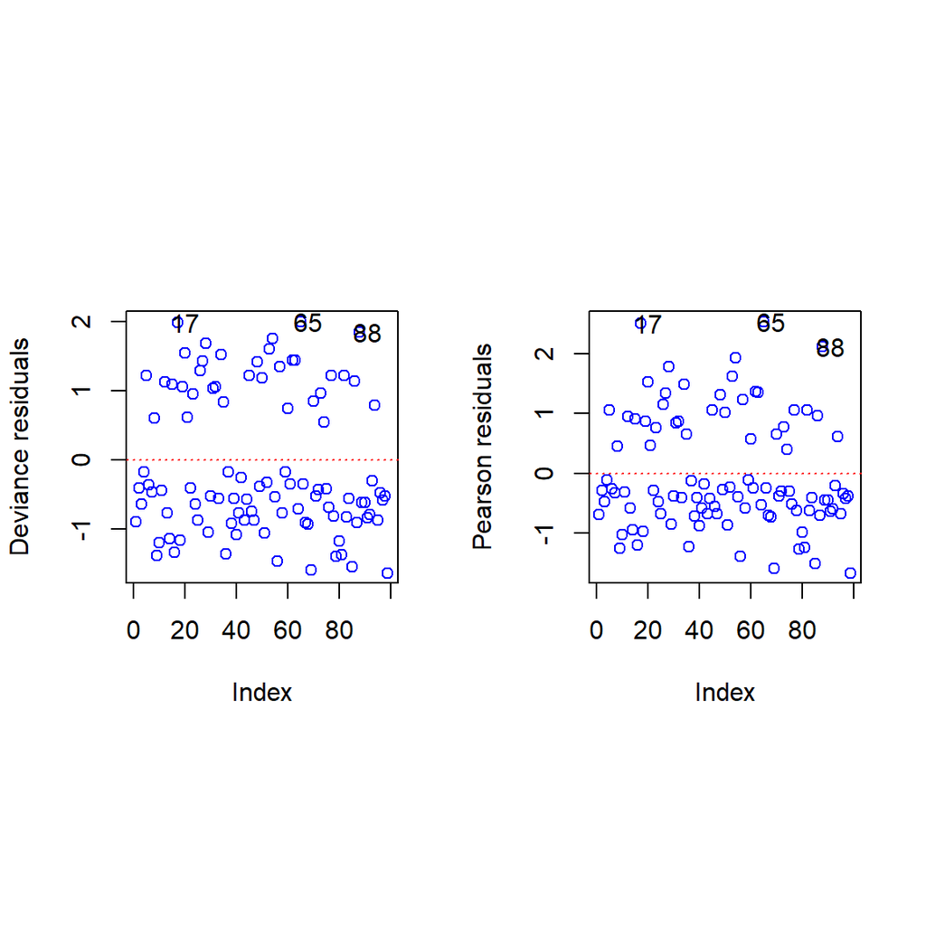

```r
# Plot the residuals
PlotResidLogist(Ronflement.glm4)
```

## **3 Robust Logistic Regression**

### 3.1 Parameter estimation and goodness of fit

```r
# Run the glmRob as it performs the estimation for a robust logistic regression
Ronflement.glmRob = glmrob(ronfle ~ age + alcool + sexe + tabac, family = binomial(link = "logit"), data = Ronflement)

# Review the logistics summary output
summary(Ronflement.glmRob)
```

```
##
## Call:  glmrob(formula = ronfle ~ age + alcool + sexe + tabac, family = binomial(link = "logit"),      data = Ronflement)
##
##
## Coefficients:
##             Estimate Std. Error z value Pr(>|z|)
## (Intercept) -3.65778    1.46890  -2.490  0.01277 *
## age          0.06026    0.02373   2.539  0.01111 *
## alcool       0.22283    0.08625   2.584  0.00978 **
## sexe        -0.71390    0.69739  -1.024  0.30599
## tabac       -1.18728    0.56713  -2.094  0.03630 *
## ---
## Signif. codes:  0 '***' 0.001 '**' 0.01 '*' 0.05 '.' 0.1 ' ' 1
## Robustness weights w.r * w.x:
##  88 weights are ~= 1. The remaining 12 ones are summarized as
##    Min. 1st Qu.  Median    Mean 3rd Qu.    Max.
##  0.3546  0.6756  0.8338  0.7745  0.9191  0.9489
##
## Number of observations: 100
## Fitted by method 'Mqle'  (in 5 iterations)
##
## (Dispersion parameter for binomial family taken to be 1)
##
## No deviance values available
## Algorithmic parameters:
##    acc    tcc
## 0.0001 1.3450
## maxit
##    50
## test.acc
##   "coef"
```

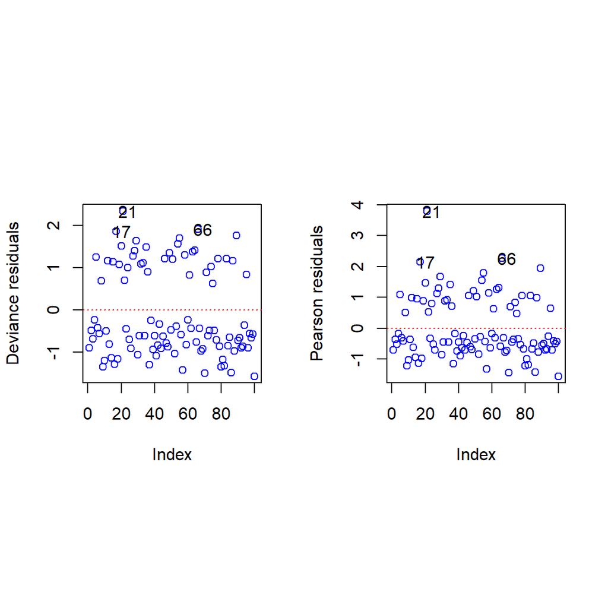

```r
# Plot the residuals
PlotResidLogistRob(Ronflement.glmRob)
```

Since the classical approach included looking at the best variables to include in the model, that exercise will not be repeated. Therefore, we can focus only on the four variables we kept. Out of the 100 observations, there are 12 that we weighted differently than 1. Those twelve points account for 12.00% of the data which is a low enough value to not consider unacceptable. Since there are additional outliers that are weighted differently, we want to ensure that the residuals follow the three assumptions from earlier. They appear to be around zero, there are no patterns/structures, and as many points are positive as there are negative. We are in the clear! Keep in mind that no outliers were removed since this is the robust model.

```r
# Goodness-of-fit results
HosLem.test(Ronflement$ronfle, fitted(Ronflement.glmRob))
```

```
##
##  Hosmer-Lemeshow goodness of fit test
##
## data:  Ronflement$ronfle, fitted(Ronflement.glmRob)
## X-squared = 6.9445, df = 8, p-value = 0.5426
```

## **Conclusion**

There are several characteristics that have been determined of a typical snorer. Based on the classical logistic regression model:

- When a customer becomes older, the odds of snoring increases by a factor of exp(0.06828) = 1.071 if all other constants are fixed. Since the value is greater than 1, it denotes that it has a positive impact on decision.
- When a customer becomes drinks more glasses per day, the odds of snoring increases by a factor of exp(0.25703) = 1.293 if all other constants are fixed. Since the value is greater than 1, it denotes that it has a positive impact on decision.
- When a customer is a woman, the odds of snoring decreases by a factor of exp(0.99308) = 0.370 if all other constants are fixed. Since the value is less than 1, it denotes that it has a negative impact on decision.
- When a customer is a smoker, the odds of snoring decreases by a factor of exp(1.44139) = 0.237 if all other constants are fixed. Since the value is less than 1, it denotes that it has a negative impact on decision.